# **Stat 107 - Fall 2020 Project**

## **By: Joseph Chan**

## **Hypothesis 1**

- We are interested in the **average arrival delay** on flights in **December** from O'Hare International Airport (Chicago) **(ORD)** to Los Angeles International Airport **(LAX)**.
- Particularly, we want to compare the average delay between American Airlines **(AA)** and United Air Lines **(UA)**.

Tasks include:

- Check if the test assumptions are satisfied (assuming we’re using z-test to compare the 2 population means).
- Plot a boxplot of the two sample (arrival delays on flights in December from ORD to LAX on American Airlines flights and on United Air Lines flights).
- State the hypothesis.
- Conduct the test at significance level α=0.05
- State the conclusion

My test hypothesis is that on average, flight delays on an American Airlines **(AA)** does not equal to the average arrival delay of United Air Lines **(UA)** on flights in December from O'Hare International Airport to Los Angeles International Airport. So **AA** != **UA**.

```python
# Importing the full flight dataset
flights = pd.read_csv('flights.csv')

# Importing code libraries
import pandas as pd
import numpy as np
import matplotlib.pyplot as plt
from scipy.stats import norm
```

- We have to find the **average arrival delay** of `AA` and `UA` flights in **December** which is `MONTH == 12` from **(ORD)** to **(LAX)**.

### **I am going to create filters to sort the flights that is important and disregard the data that isn't important.**

**Filters:**

- `'MONTH' == 12` filters only the flights in December.
- `'AIRLINE' == 'AA'` or `'UA'` filters only American Airlines and United Air Lines.
- `'ORIGIN_AIRPORT' == 'ORD'` filters only flights starting in O'Hare International Airport.
- `'DESTINATION_AIRPORT' == 'LAX'` filters only flights ending in Los Angeles International Airport.
- `'ARRIVAL_DELAY' == Unknown` We do not know the arrival delay.

`AA` stands for American Airlines and `AU` stands for United Air lines and the `.dropna()` dataframe removes any missing value which we will use for `'ARRIVAL_DELAY'`.

```python
AA = flights.loc[(flights['MONTH'] == 12) &
    (flights['AIRLINE'] == 'AA') &
    (flights['ORIGIN_AIRPORT'] == 'ORD') &
    (flights['DESTINATION_AIRPORT'] == 'LAX'),
    'ARRIVAL_DELAY'].dropna()

UA = flights.loc[(flights['MONTH'] == 12) &
    (flights['AIRLINE'] == 'UA') &
    (flights['ORIGIN_AIRPORT'] == 'ORD') &
    (flights['DESTINATION_AIRPORT'] == 'LAX'),
    'ARRIVAL_DELAY'].dropna()
```

- Boxplot graph of the two samples (arrival delays on flights in December from ORD to LAX on American Airlines flights and on United Air Lines flights).

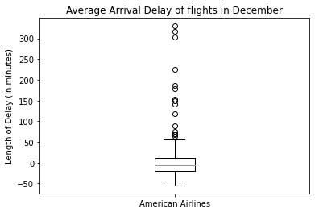

```python
plt.boxplot([AA], labels = ['American Airlines'])
plt.ylabel('Length of Delay (in minutes)')
plt.title('Average Arrival Delay of flights in December')
plt.show()
```

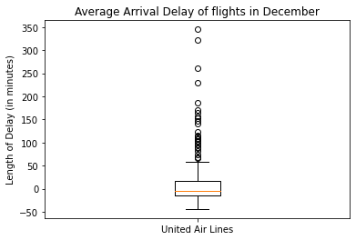

```python
plt.boxplot([UA], labels = ['United Air Lines'])
plt.ylabel('Length of Delay (in minutes)')
plt.title('Average Arrival Delay of flights in December')
plt.show()
```

- Average arrival delay and standard deviation:

```python
print('The average arrival delay in December from ORD to LAX is:', '\n\nAmerican Airlines:',AA.mean(),'minutes''\nUnited Air Lines:',UA.mean(),'minutes')
print('\nThe standard deviation of delays in December from ORD to LAX is:', '\n\nAmerican Airlines:',AA.std(),'minutes''\nUnited Air Lines:',UA.std(),'minutes')
```

```
The average arrival delay in December from ORD to LAX is:

American Airlines: 4.6571428571428575 minutes
United Air Lines: 10.30794701986755 minutes

The standard deviation of delays in December from ORD to LAX is:

American Airlines: 48.04713507525805 minutes
United Air Lines: 49.81975354828445 minutes
```

- p-value, z-value, and significance level

To find the z-value, I have to compare the probability of `AA` to `UA` to see if pA > pB and then multiply by -1 to find the inverse.

```python
def find_z(a,b):
    return (a.mean() - b.mean()) / (((a.std()**2)/a.size) + ((b.std()**2)/b.size))**0.5

# z-value
z = find_z(AA,UA)
print('z-value =',z)

# p-value
p = 2*norm.cdf(z)
print('p-value = ',p)

# Comparison for later
hypothesis_1 = p
```

```
z-value = -1.3926811323141544
p-value =  0.16371623660393797
```

### **Conclusion**

The p-value that we have obtained is 0.16 and since the significance level of α = 0.05, then our p-value is greater than the significance level. This means we **fail to reject** the null hypothesis. Therefore, the dataset does not provide the evidence that on average, American Airlines has a different arrival delay time than United Air Lines.

## **Hypothesis 2**

- We want to find the **probability of flights delaying over an hour** in **December** from O'Hare International Airport `ORD` to Los Angeles International Airport `LAX`.

Tasks include:

- Check if the test assumptions are satisfied (assuming we’re using z-test to compare the 2 population proportions).
- State the hypothesis.
- Conduct the test at significance level α=0.05
- State the conclusion.

My test hypothesis is that on average, the probability of American Airlines flights delaying over an hour is **the same as** United Air Lines.

### **I am going to create filters so the only data that is present are flights with delays that are over an hour.**

```python
# 1 hour = 60 minutes so (> 60)
AA_late = AA.loc[flights['ARRIVAL_DELAY'] > 60]
UA_late = UA.loc[flights['ARRIVAL_DELAY'] > 60]
```

#### **Finding the probability:**

```python
# late_1 & late_2 are the flights that are delayed over an hour
# regular_1 & regular_2 are the regular flights without the filter
late_1 = AA_late.size
late_2 = UA_late.size
regular_1 = AA.size
regular_2 = UA.size

# probability
probability_1 = (late_1 / regular_1)
probability_2 = (late_2 / regular_2)

p_hat = ((late_1 + late_2) / (regular_1 + regular_2))

# z-value
z = (probability_1 - probability_2) / (p_hat*(1-p_hat) * (1 / regular_1 + 1 / regular_2))**0.5
print('z-value =', z)

# p-value
p = norm.cdf(z)
print('p-value =', p)

# Comparison for later
hypothesis_2 = p
```

```
z-value = -1.5318672735156422
p-value = 0.06277759542136989
```

## **Hypothesis 3**

- Using the above hypothesis tests as example, choose 2 populations that you’re interested in comparing.
- You must use either the hypothesis test for 2 means or the hypothesis test for 2 proportions.
- State the question that you’re interesed in answering by conducting this test.
- Check if the test assumptions are satisfied.
- State the hypotheses.
- Conduct the test at significance level α=0.05
- State the conclusion.

My test hypothesis is that on average, flight delays on a Alaska Airlines Inc. **(AS)** does not equal to the average arrival delay of United Air Lines Inc. **(UA)** on flights in December from Seattle-Tacoma International Airport `SEA` to San Francisco International Airport `SFO`. So **AS** != **UA**.

### **I am going to create filters to sort the flights that is important and disregard the data that isn't important.**

**Filters:**

`AS` stands for Alaska Airlines Inc. and `UA` stands for United Air Lines Inc. and the `.dropna()` dataframe removes any missing value which we will use for `'ARRIVAL_DELAY'`.

```python
# I am filtering the data that is necessary to proof my hypothesis
# Anything else that does not match the requirements for the data needed will be disregarded.
AS = flights.loc[(flights['MONTH'] == 12) &
    (flights['AIRLINE'] == 'AS') &
    (flights['ORIGIN_AIRPORT'] == 'SEA') &
    (flights['DESTINATION_AIRPORT'] == 'SFO'),
    'ARRIVAL_DELAY'].dropna()

UA = flights.loc[(flights['MONTH'] == 12) &
    (flights['AIRLINE'] == 'UA') &
    (flights['ORIGIN_AIRPORT'] == 'SEA') &
    (flights['DESTINATION_AIRPORT'] == 'SFO'),
    'ARRIVAL_DELAY'].dropna()
```

**Finding the p-value, z-value, and significance level:**

- Using the same code as the one in hypothesis 1.

```python
# z-value
z = find_z(AS,UA)
print('z-value =',z)

# p-value
p = 2*norm.cdf(z1)
print('p-value = ',p)

# Comparison for later
hypothesis_3 = p
```

[output not shown]

The p-value that we have obtained is 0.22 and since the significance level of α = 0.05, then our p-value is greater than the significance level. This means we **fail to reject** the null hypothesis. Therefore, the dataset does not provide the evidence that on average, Alaska Airlines Inc. has a different arrival delay time than United Air Lines.

## **Multiple Comparison**

- Using the Bonferroni correction conduct the 3 above tests with a family-wise error rate of α=0.05.
- State the conclusion for all 3 tests.

### **Calculating the alpha**

To calculate the alpha value, I am going to divide the significance level value `O.05` to the number of hypothesis test that we did `3`.

```python
alpha1 = 0.05 / 3
alpha1
```

```
0.016666666666666666
```

Procedure:

- Take each individual p-value from the hypothesis tests that we concluded and subtract that from the value of `alpha1`.
- If p-value > significance value, we fail to reject the null hypothesis.
- If p-value < significance value, we reject the null hypothesis.
- If difference is positive, p-value is > significance value.
- If difference is negative, p-value is < significance value.

```python
# Hypothesis 1
hypothesis_1 - alpha1
```

```
0.1470495699372713
```

```python
# Hypothesis 2
hypothesis_2 - alpha1
```

```
0.046110928754703226
```

```python
# Hypothesis 3
hypothesis_3 - alpha1
```

```
0.20297551373250494
```

### **Conclusion**

Since all 3 hypothesis test are greater than 0, this means that the p-value is greater than the significance value. Therefore, we **fail to reject the null hypothesis**.